# Case Study 01 - GDP ANALYSIS

Paul Widhalm

November 1, 2016

## INTRODUCTION

This document takes a look at the GDP for various countries and answers some basic questions about their GDP such as their ranking and quantile participation.

## DOWNLOAD THE DATA SETS

```r
    #install necessary library if needed
    install.packages("downloader",repos="http://cran.rstudio.com/")
```

```r
    library("downloader")

    download("https://d396qusza40orc.cloudfront.net/getdata%2Fdata%2FGDP.csv","gdp190.csv")
    download("https://d396qusza40orc.cloudfront.net/getdata%2Fdata%2FEDSTATS_Country.csv","country.csv")
```

## READ THE DOWNLOADED FILES INTO TABLES

```r
    GDP<-read.csv("gdp190.csv")
    STATS<-read.csv("country.csv")
```

## SUMMARY INFORMATION ON THE DATA - GDP

```r
    str(GDP)
```

```
## 'data.frame':    330 obs. of  10 variables:
##  $ X                          : Factor w/ 229 levels "","ABW","ADO",..: 1 1 1 1 215 38 102 51 68 72 ...
##  $ Gross.domestic.product.2012: Factor w/ 195 levels "",".. Not available.  ",..: 1 1 195 1 3 104 115 126 137 148 ...
##  $ X.1                        : logi  NA NA NA NA NA NA ...
##  $ X.2                        : Factor w/ 230 levels "","  East Asia & Pacific",..: 1 1 67 1 219 51 108 83 78 218 ...
##  $ X.3                        : Factor w/ 207 levels ""," 1,008 "," 1,129 ",..: 1 191 207 1 40 178 143 100 66 63 ...
##  $ X.4                        : Factor w/ 7 levels "","a","b","c",..: 1 1 1 1 1 1 1 1 1 1 ...
##  $ X.5                        : logi  NA NA NA NA NA NA ...
##  $ X.6                        : logi  NA NA NA NA NA NA ...
##  $ X.7                        : logi  NA NA NA NA NA NA ...
##  $ X.8                        : logi  NA NA NA NA NA NA ...
```

```r
    head(GDP)
```

```
##     X Gross.domestic.product.2012 X.1           X.2          X.3 X.4 X.5
## 1                                  NA                                 NA
## 2                                  NA               (millions of      NA
## 3                         Ranking  NA       Economy  US dollars)      NA
## 4                                  NA                                 NA
## 5 USA                           1  NA United States  16,244,600       NA
## 6 CHN                           2  NA         China   8,227,103       NA
##   X.6 X.7 X.8
## 1  NA  NA  NA
## 2  NA  NA  NA
## 3  NA  NA  NA
## 4  NA  NA  NA
## 5  NA  NA  NA
## 6  NA  NA  NA
```

```r
    names(GDP)
```

```
##  [1] "X"                           "Gross.domestic.product.2012"
##  [3] "X.1"                         "X.2"
##  [5] "X.3"                         "X.4"
##  [7] "X.5"                         "X.6"
##  [9] "X.7"                         "X.8"
```

```r
    dim(GDP)
```

```
## [1] 330  10
```

## SUMMARY INFORMATION ON THE DATA - STATS

```r
    str(STATS)
```

```
## 'data.frame':    234 obs. of  31 variables:
##  $ CountryCode                                      : Factor w/ 234 levels "ABW","ADO","AFG",..: 1 2 3 4 5 6 7 8 9 10 ...
##  $ Long.Name                                        : Factor w/ 234 levels "American Samoa",..: 5 104 57 99 108 226 4 109 1 2 ...
##  $ Income.Group                                     : Factor w/ 6 levels "","High income: nonOECD",..: 2 2 4 5 6 2 6 5 6 6 ...
##  $ Region                                           : Factor w/ 8 levels "","East Asia & Pacific",..: 4 3 7 8 3 5 4 3 2 4 ...
##  $ Lending.category                                 : Factor w/ 4 levels "","Blend","IBRD",..: 1 1 4 4 3 1 3 2 1 3 ...
##  $ Other.groups                                     : Factor w/ 3 levels "","Euro area",..: 1 1 3 1 1 1 1 1 1 1 ...
##  $ Currency.Unit                                    : Factor w/ 155 levels "","Afghan afghani",..: 8 49 2 5 3 144 6 7 145 44 ...
##  $ Latest.population.census                         : Factor w/ 28 levels "","1970","1979",..: 17 28 3 2 18 22 18 18 17 18 ...
##  $ Latest.household.survey                          : Factor w/ 56 levels "","CPS (monthly)",..: 1 1 39 38 40 1 1 16 1 1 ...
##  $ Special.Notes                                    : Factor w/ 70 levels "","A simple multiplier is used to convert the national currencies of EMU members to euros. The following irrevocable euro conversi"| __truncated__,..: 1 1 27 1 1 1 1 1 1 63 ...
##  $ National.accounts.base.year                      : Factor w/ 44 levels "","1954","1973",..: 25 1 38 28 1 25 22 1 1 18 ...
##  $ National.accounts.reference.year                 : int  NA NA NA NA 1996 NA NA 1996 NA NA ...
##  $ System.of.National.Accounts                      : int  NA NA NA NA 1993 NA 1993 1993 NA NA ...
##  $ SNA.price.valuation                              : Factor w/ 3 levels "","VAB","VAP": 1 1 2 3 2 2 2 2 1 2 ...
```

[output cut: 17 more lines]

```r
    head(STATS)
```

```
##   CountryCode                    Long.Name         Income.Group
## 1         ABW                        Aruba High income: nonOECD
## 2         ADO      Principality of Andorra High income: nonOECD
## 3         AFG Islamic State of Afghanistan           Low income
## 4         AGO  People's Republic of Angola  Lower middle income
## 5         ALB          Republic of Albania  Upper middle income
## 6         ARE         United Arab Emirates High income: nonOECD
##                       Region Lending.category Other.groups  Currency.Unit
## 1  Latin America & Caribbean                                Aruban florin
## 2      Europe & Central Asia                                         Euro
## 3                 South Asia              IDA         HIPC Afghan afghani
## 4         Sub-Saharan Africa              IDA              Angolan kwanza
## 5      Europe & Central Asia             IBRD                Albanian lek
## 6 Middle East & North Africa                                U.A.E. dirham
##   Latest.population.census  Latest.household.survey
```

[output cut: 83 more lines]

```r
    names(STATS)
```

```
##  [1] "CountryCode"
##  [2] "Long.Name"
##  [3] "Income.Group"
##  [4] "Region"
##  [5] "Lending.category"
##  [6] "Other.groups"
##  [7] "Currency.Unit"
##  [8] "Latest.population.census"
##  [9] "Latest.household.survey"
## [10] "Special.Notes"
## [11] "National.accounts.base.year"
## [12] "National.accounts.reference.year"
## [13] "System.of.National.Accounts"
## [14] "SNA.price.valuation"
## [15] "Alternative.conversion.factor"
```

[output cut: 16 more lines]

```r
    dim(STATS)
```

```
## [1] 234  31
```

## START CLEANING UP THE DATA FILES

## first make sure the necessary libraries are installed

```r
    # install necessary library if needed
    install.packages("tidyr",repos="http://cran.rstudio.com/")
    library("tidyr")
    install.packages("dplyr",repos="http://cran.rstudio.com/")
    library("dplyr")
```

## CLEAN UP GDP

```r
    dsGDP<-GDP[c(1,2,5)]
    names(dsGDP)<-c("country","ranking","GDP")

    # clear out invalid text segments
    dsGDP$GDP <- gsub("\\(millions of", "", dsGDP$GDP)
    dsGDP$GDP <- gsub("US dollars\\)", "", dsGDP$GDP)
    dsGDP$ranking <- gsub("Gross domestic product 2012", "", dsGDP$ranking)
    dsGDP$ranking <- gsub("Ranking", "", dsGDP$ranking)
    # select the non-empty rows
    dsGDP <- dsGDP[5:331,]
    dsGDP <- dsGDP[dsGDP$country != "", c(1,2,3)]
    # reformat the number fields
    dsGDP$GDP <- gsub(",", "", dsGDP$GDP)
    dsGDP$GDP <- as.integer(dsGDP$GDP)
    dsGDP$ranking <- as.integer(dsGDP$ranking)

    # show the final dataset
    #dsGDP

    str(dsGDP)
```

```
## 'data.frame':    229 obs. of  3 variables:
##  $ country: Factor w/ 229 levels "","ABW","ADO",..: 215 38 102 51 68 72 28 174 99 93 ...
##  $ ranking: int  1 2 3 4 5 6 7 8 9 10 ...
##  $ GDP    : int  16244600 8227103 5959718 3428131 2612878 2471784 2252664 2014775 2014670 1841710 ...
```

```r
    head(dsGDP)
```

```
##    country ranking      GDP
## 5      USA       1 16244600
## 6      CHN       2  8227103
## 7      JPN       3  5959718
## 8      DEU       4  3428131
## 9      FRA       5  2612878
## 10     GBR       6  2471784
```

```r
    summary(dsGDP)
```

```
##     country       ranking            GDP
##  ABW    :  1   Min.   :  1.00   Min.   :      40
##  ADO    :  1   1st Qu.: 48.25   1st Qu.:    7772
##  AFG    :  1   Median : 95.50   Median :   36871
##  AGO    :  1   Mean   : 95.49   Mean   : 1453710
##  ALB    :  1   3rd Qu.:142.75   3rd Qu.:  262939
##  (Other):223   Max.   :190.00   Max.   :72440449
##  NA's   :  1   NA's   :39       NA's   :25
```

## CLEAN UP STATS

```r
    dsSTATS<-STATS[c(1,2,3)]
    names(dsSTATS)<-c("country","country_name","income_group")

    # clear out invalid text segments
    dsSTATS$country <- gsub("CountryCode", "", dsSTATS$country)
    dsSTATS$country_name <- gsub("Long Name", "", dsSTATS$country_name)
    dsSTATS$income_group <- gsub("Income Group", "", dsSTATS$income_group)

    # select the non-empty rows
    dsSTATS <- dsSTATS[2:331,]
    dsSTATS<-subset(dsSTATS, !is.na(income_group))
    # show the final dataset
    #dsSTATS

    str(dsSTATS)
```

```
## 'data.frame':    233 obs. of  3 variables:
##  $ country     : chr  "ADO" "AFG" "AGO" "ALB" ...
##  $ country_name: chr  "Principality of Andorra" "Islamic State of Afghanistan" "People's Republic of Angola" "Republic of Albania" ...
##  $ income_group: chr  "High income: nonOECD" "Low income" "Lower middle income" "Upper middle income" ...
```

```r
    head(dsSTATS)
```

```
##   country                 country_name         income_group
## 2     ADO      Principality of Andorra High income: nonOECD
## 3     AFG Islamic State of Afghanistan           Low income
## 4     AGO  People's Republic of Angola  Lower middle income
## 5     ALB          Republic of Albania  Upper middle income
## 6     ARE         United Arab Emirates High income: nonOECD
## 7     ARG           Argentine Republic  Upper middle income
```

```r
    summary(dsSTATS)
```

```
##    country          country_name       income_group
##  Length:233         Length:233         Length:233
##  Class :character   Class :character   Class :character
##  Mode  :character   Mode  :character   Mode  :character
```

## MERGE THE STATS AND GDP DATASETS

```r
    m<-merge(dsSTATS,dsGDP,"country")
    dim(m)
```

```
## [1] 223   5
```

## Question #1: 223 country IDs matched between the two datasets

```r
    #arrange the data by GDP and get the 13th country
   m <- subset(m, !is.na(GDP))
   dim(m)
```

```
## [1] 202   5
```

```r
   library("dplyr")
   m<-arrange(m,GDP)
   head(m,13)
```

```
##    country                                 country_name
## 1      TUV                                       Tuvalu
## 2      KIR                         Republic of Kiribati
## 3      MHL             Republic of the Marshall Islands
## 4      PLW                            Republic of Palau
## 5      STP Democratic Republic of São Tomé and Principe
## 6      FSM               Federated States of Micronesia
## 7      TON                             Kingdom of Tonga
## 8      DMA                     Commonwealth of Dominica
## 9      COM                         Union of the Comoros
## 10     WSM                                        Samoa
## 11     VCT               St. Vincent and the Grenadines
## 12     GRD                                      Grenada
## 13     KNA                          St. Kitts and Nevis
##           income_group ranking GDP
## 1  Lower middle income     190  40
## 2  Lower middle income     189 175
## 3  Lower middle income     188 182
## 4  Upper middle income     187 228
## 5  Lower middle income     186 263
## 6  Lower middle income     185 326
## 7  Lower middle income     184 472
## 8  Upper middle income     183 480
## 9           Low income     182 596
## 10 Lower middle income     181 684
## 11 Upper middle income     180 713
## 12 Upper middle income     178 767
## 13 Upper middle income     178 767
```

## Question #2: The 13th country after sorting by GDP is: St. Kitts and Nevis

```r
    #filter for income group High Income OECD
    OECD <- m[m$income_group=="High income: OECD",c(2,4)]
    head(OECD)
```

```
##                  country_name ranking
## 67        Republic of Iceland     122
## 109      Republic of Slovenia      80
## 115 Grand Duchy of Luxembourg      74
## 126           Slovak Republic      63
## 131       Republic of Hungary      58
## 134               New Zealand      55
```

```r
    summary(OECD)
```

```
##  country_name          ranking
##  Length:30          Min.   :  1.00
##  Class :character   1st Qu.: 12.25
##  Mode  :character   Median : 24.50
##                     Mean   : 32.97
##                     3rd Qu.: 45.75
##                     Max.   :122.00
```

```r
    mean(OECD[["ranking"]])
```

```
## [1] 32.96667
```

```r
    #filter for income group High Income nonOECD
    NOECD <- m[m$income_group=="High income: nonOECD",c(2,4)]
    #NOECD
    summary(NOECD)
```

```
##  country_name          ranking
##  Length:22          Min.   : 19.00
##  Class :character   1st Qu.: 57.25
##  Mode  :character   Median : 93.50
##                     Mean   : 88.77
##                     3rd Qu.:112.25
##                     Max.   :153.00
```

```r
    mean(NOECD[["ranking"]])
```

```
## [1] 88.77273
```

## Question #3: The average GDP ranking for OECD is: 33 and the average GDP ranking for non-OECD is: 89

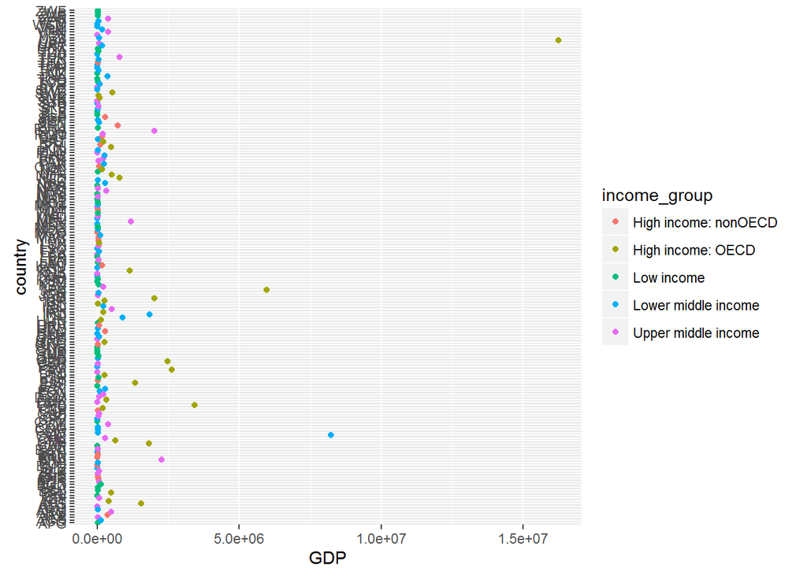

```r
    #install necessary library if needed
    install.packages("ggplot2",repos="http://cran.rstudio.com/")
    library("ggplot2")

    plotz <- m[1:198,]
    plotz <- plotz[plotz$income_group != "", c(1,2,3,4,5)]

    ggplot(data=plotz, aes(x=GDP,y=country , color=income_group))+geom_point()
```

## Question #4 Analysis of the Plot: The GDP for the High-Income OECD is has the largest number of countries with a high GDP. Most of the other income groups are all within a very tight margin.

```r
    #analysis on the ranks for making quantiles
    qdata<-plotz
    qmean<-mean(qdata[["ranking"]])
    qstd<-sd(qdata[["ranking"]])

    #calculate the quantiles
    q1<-qnorm(.2,qmean,qstd)
    q2<-qnorm(.4,qmean,qstd)
    q3<-qnorm(.6,qmean,qstd)
    q4<-qnorm(.8,qmean,qstd)
    q5<-qnorm(.99,qmean,qstd)

    #extract the quantile data members
    q1Data<-qdata[qdata$ranking<=q1, c(1,2,3,4,5)]
    q2Data<-qdata[qdata$ranking<=q2 & qdata$ranking>q1, c(1,2,3,4,5)]
    q3Data<-qdata[qdata$ranking<=q3 & qdata$ranking>q2, c(1,2,3,4,5)]
    q4Data<-qdata[qdata$ranking<=q4 & qdata$ranking>q3, c(1,2,3,4,5)]
    q5Data<-qdata[qdata$ranking<=q5 & qdata$ranking>q4, c(1,2,3,4,5)]

    #summary of quantile data groups
    summary(q1Data)
```

```
##    country          country_name       income_group          ranking
##  Length:48          Length:48          Length:48          Min.   : 1.00
##  Class :character   Class :character   Class :character   1st Qu.:12.75
##  Mode  :character   Mode  :character   Mode  :character   Median :24.50
##                                                           Mean   :24.50
##                                                           3rd Qu.:36.25
##                                                           Max.   :48.00
##       GDP
##  Min.   :  205789
##  1st Qu.:  268216
##  Median :  486528
##  Mean   : 1397618
##  3rd Qu.: 1375326
##  Max.   :16244600
```

```r
    summary(q2Data)
```

```
##    country          country_name       income_group          ranking
##  Length:33          Length:33          Length:33          Min.   :49
##  Class :character   Class :character   Class :character   1st Qu.:57
##  Mode  :character   Mode  :character   Mode  :character   Median :65
##                                                           Mean   :65
##                                                           3rd Qu.:73
##                                                           Max.   :81
##       GDP
##  Min.   : 45104
##  1st Qu.: 58769
##  Median : 73672
##  Mean   :100842
##  3rd Qu.:155820
##  Max.   :203790
```

```r
    summary(q3Data)
```

```
##    country          country_name       income_group          ranking
##  Length:27          Length:27          Length:27          Min.   : 82.0
##  Class :character   Class :character   Class :character   1st Qu.: 88.5
##  Mode  :character   Mode  :character   Mode  :character   Median : 95.0
##                                                           Mean   : 95.0
##                                                           3rd Qu.:101.5
##                                                           Max.   :108.0
##       GDP
##  Min.   :18434
##  1st Qu.:23044
##  Median :28242
##  Mean   :29868
##  3rd Qu.:36871
##  Max.   :43582
```

```r
    summary(q4Data)
```

```
##    country          country_name       income_group          ranking
##  Length:32          Length:32          Length:32          Min.   :109.0
##  Class :character   Class :character   Class :character   1st Qu.:116.8
##  Mode  :character   Mode  :character   Mode  :character   Median :124.5
##                                                           Mean   :124.8
##                                                           3rd Qu.:133.2
##                                                           Max.   :141.0
##       GDP
##  Min.   : 7253
##  1st Qu.: 9914
##  Median :12768
##  Mean   :12401
##  3rd Qu.:14567
##  Max.   :18377
```

```r
    summary(q5Data)
```

```
##    country          country_name       income_group          ranking
##  Length:48          Length:48          Length:48          Min.   :142.0
##  Class :character   Class :character   Class :character   1st Qu.:153.8
##  Mode  :character   Mode  :character   Mode  :character   Median :166.5
##                                                           Mean   :166.1
##                                                           3rd Qu.:178.0
##                                                           Max.   :190.0
##       GDP
##  Min.   :  40
##  1st Qu.: 767
##  Median :1804
##  Mean   :2592
##  3rd Qu.:4206
##  Max.   :7103
```

```r
    #make a table of income vs ranking
    table(q1Data$ranking,q1Data$income_group)
```

```
##
##      High income: nonOECD High income: OECD Lower middle income
##   1                     0                 1                   0
##   2                     0                 0                   1
##   3                     0                 1                   0
##   4                     0                 1                   0
##   5                     0                 1                   0
##   6                     0                 1                   0
##   7                     0                 0                   0
##   8                     0                 0                   0
##   9                     0                 1                   0
##   10                    0                 0                   1
##   11                    0                 1                   0
##   12                    0                 1                   0
##   13                    0                 1                   0
```

[output cut: 85 more lines]

## Question #5 - How many countries are Lower middle income but among the 38 nations with highest GDP? The answer is 9.

## Conclusion: The U.S. has, by far, the largest GDP and skews some of the analysis being done. There is a great many more countries with low GDP and low income. An interesting observation was the number of countries that have a high GDP but are considered low-middle income.